# MGT6203 Project Team-115: Employee Performance

2024-11-12

```r
library(dplyr)
library(tidyverse)
```

```r
library(ggplot2)
library(zoo)
library(xts)
library(ggpmisc)
library(car)
library(psych)
library(e1071)
library(corrplot)
library(MASS)
```

## Model Selection

**Import and Prepare Data**

```r
perf = read.csv("employee_performance.csv", header=TRUE) #reads data
perf$Education_Level = as.factor(perf$Education_Level)
perf$Job_Satisfaction = as.factor(perf$Job_Satisfaction)
perf$Department = as.factor(perf$Department)
perf$Work_Life_Balance = as.factor(perf$Work_Life_Balance)
perf$Promotions_Last_5_Years = as.factor(perf$Promotions_Last_5_Years)
# # add total hours
# perf$Total_Hours_Per_Week = perf$Work_Hours_Per_Week + perf$Overtime_Hours_Per_Week
perf$Salary = perf$Salary/1000 # bring values to the same order of magnitude
perf$Annual_Bonus = perf$Annual_Bonus/100 # bring values to the same order of magnitude
dim(perf)
```

```
## [1] 10000    14
```

```r
# head(perf)
# Check missing values
cat("There are",sum(is.na(perf)), "missing values in the dataset")
```

```
## There are 0 missing values in the dataset
```

**divide into training and test sets**

```r
set.seed(2024)
testRows = sample(nrow(perf),0.2*nrow(perf))
perf_test = perf[testRows, ]
perf_train = perf[-testRows, ]
row.names(perf_train) <- NULL
# head(perf_train)
# head(perf_test)
dim(perf_train )
```

```
## [1] 8000   14
```

**Feature Significance and Feature Selection**

**Feature Selection with Partial F test**

From EDA, we decided there is no multicollinearity in the predictors. We also found only Age, Experience, and Work_Hours_Per_Week seem to be correlated with performance score. So we will compare the full model with all features with the reduced model with only these three predictors, using partial F test.

```r
MLR_full <- lm(Performance_Score ~ ., data = perf_train)
MLR_reduced <- lm(Performance_Score ~ Age + Experience + Work_Hours_Per_Week , data = perf_train)
# summary(MLR_reduced)
# summary(MLR_full)
anova(MLR_reduced, MLR_full)
```

```
## Analysis of Variance Table
##
## Model 1: Performance_Score ~ Age + Experience + Work_Hours_Per_Week
## Model 2: Performance_Score ~ Age + Salary + Experience + Education_Level +
##     Job_Satisfaction + Department + Work_Life_Balance + Annual_Bonus +
##     Commute_Time + Work_Hours_Per_Week + Promotions_Last_5_Years +
##     Training_Hours_Last_Year + Overtime_Hours_Per_Week
##   Res.Df    RSS Df Sum of Sq      F  Pr(>F)
## 1   7996 801477
## 2   7970 796937 26    4540.2 1.7464 0.01078 *
## ---
## Signif. codes:  0 '***' 0.001 '**' 0.01 '*' 0.05 '.' 0.1 ' ' 1
```

p-value is 0.01078, indicating the subset of coefficients are statistical significant at alpha = 0.05 level. So we have to reject the null hypothesis that the coefficients for those predictors are equal to zero.

But with n = 8000, which is a large number and may cause inflated significance in predictors.

**Handling Inflated Statistical Significance**

“Inflated” Statistical Significance

```r
## Approach: Subsample 10% of the initial data sample & repeat 100 times

count = 1
n = nrow(perf)
B = 100
ncoef = dim(summary(MLR_full)$coeff)[1]
pv_matrix = matrix(0,nrow = ncoef,ncol = B)

while (count <= B) {
  subsample = sample(n, floor(n*0.1), replace=FALSE)
  subdata = perf[subsample,]
  submod = lm(Performance_Score ~ .,data=subdata)
  pv_matrix[,count] = summary(submod)$coeff[,4]
  count = count + 1
}

# Count pvalues smaller than 0.01 across the 100 (sub)models
alpha = 0.01
pv_significant = rowSums(pv_matrix <= alpha)
pv_significant
```

```
##  [1]   1 100   0 100   0   0   1   3   0   1   0   5   1   0   0   2   1   1   1
## [20]   1   1   4   0 100   1   1   1   0   1   3
```

```r
## Which regression coefficients are statistically significant?
idx_scoef = which(pv_significant>=95)
idx_scoef
```

```
## [1]  2  4 24
```

```r
## Show the p-values of the significant coefficients in MLR_full
cbind(summary(MLR_full)$coeff[idx_scoef,c(1,4)],
      Freq=pv_significant[idx_scoef])
```

```
##                      Estimate     Pr(>|t|) Freq
## Age                 0.2980302 4.06172e-314  100
## Experience          0.5046134  0.00000e+00  100
## Work_Hours_Per_Week 0.3994494  0.00000e+00  100
```

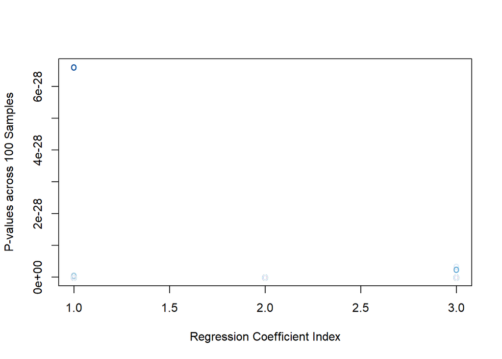

```r
## Plot the 100 p-values of the significant coefficients
matplot(pv_matrix[idx_scoef,],
     xlab="Regression Coefficient Index",
     ylab="P-values across 100 Samples",
     type="p",
     pch="o",
     col=blues9)
```

```r
# Which regression coefficients are not statistically significant?
idx_icoef = which(pv_significant<=95)
# Show the p-values of the non-significant coefficients in model2
cbind(summary(MLR_full)$coeff[idx_icoef,c(1,4)],
      Freq=pv_significant[idx_icoef])
```

```
##                                Estimate   Pr(>|t|) Freq
## (Intercept)                 1.637662077 0.08478261    1
## Salary                     -0.010138585 0.17315433    0
## Education_LevelBachelor     0.401125566 0.25728071    0
## Education_LevelHigh School  0.272053816 0.44076486    0
## Education_LevelMaster       0.759505906 0.03002668    1
## Education_LevelPhD          0.836473979 0.01806116    3
## Job_Satisfaction2           0.287814932 0.41577015    0
## Job_Satisfaction3           0.452780223 0.20388841    1
## Job_Satisfaction4           0.466752922 0.19033666    0
## Job_Satisfaction5           0.914510442 0.01044834    5
## DepartmentFinance          -0.487308804 0.20881463    1
## DepartmentHR               -0.558564285 0.15410170    0
## DepartmentMarketing        -0.733126972 0.06132207    0
## DepartmentOperations       -0.375041648 0.33324005    2
## DepartmentSales            -0.397888421 0.30885020    1
## Work_Life_Balance2          0.046985490 0.89436569    1
## Work_Life_Balance3         -0.106026573 0.76518851    1
## Work_Life_Balance4          0.845025384 0.01552825    1
## Work_Life_Balance5          0.578657878 0.10525580    1
## Annual_Bonus               -0.008589911 0.12531437    4
## Commute_Time                0.004740941 0.16045255    0
## Promotions_Last_5_Years1   -0.581546788 0.10511610    1
## Promotions_Last_5_Years2   -0.035255179 0.92135243    1
## Promotions_Last_5_Years3   -0.208941822 0.55723827    1
## Promotions_Last_5_Years4   -0.089631183 0.79951835    0
## Training_Hours_Last_Year   -0.006872766 0.07589753    1
## Overtime_Hours_Per_Week    -0.025371107 0.18883620    3
```

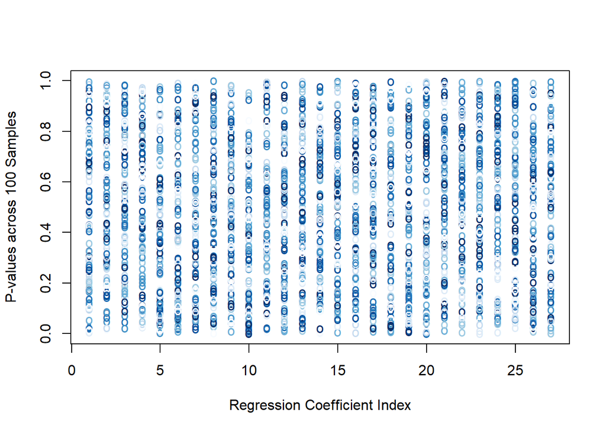

```r
# Plot the 100 p-values of the non-significant coefficients
matplot(pv_matrix[idx_icoef,],
     xlab="Regression Coefficient Index",
     ylab="P-values across 100 Samples",
     type="p",
     pch="o",
     col=blues9)
```

This study confirmed that only three predictors are statistically significant in explaining the variance in performance score:

Age  
Experience  
Work_Hours_Per_Week

**Forward and Backward Stepwise Feature Selection**

```r
# Forward
minimum = lm(Performance_Score ~ 1, data = perf_train)
step(minimum, scope=list(lower=minimum,
                         upper=MLR_full), direction="forward")
```

```
## Start:  AIC=42067.41
## Performance_Score ~ 1
##
##                            Df Sum of Sq     RSS   AIC
## + Experience                1    403530 1133516 39633
## + Work_Hours_Per_Week       1    172463 1364583 41117
## + Age                       1    161834 1375212 41179
## + Salary                    1      1194 1535852 42063
## + Work_Life_Balance         4      2091 1534955 42065
## + Commute_Time              1       922 1536124 42065
## + Training_Hours_Last_Year  1       586 1536460 42066
## + Overtime_Hours_Per_Week   1       387 1536659 42067
## <none>                                  1537046 42067
## + Annual_Bonus              1       380 1536666 42067
## + Job_Satisfaction          4      1514 1535532 42068
## + Promotions_Last_5_Years   4      1234 1535812 42069
## + Education_Level           4       859 1536187 42071
## + Department                5       923 1536123 42073
##
## Step:  AIC=39633.1
## Performance_Score ~ Experience
##
##                            Df Sum of Sq     RSS   AIC
## + Work_Hours_Per_Week       1    173426  960090 38307
## + Age                       1    161289  972227 38407
## + Commute_Time              1       663 1132853 39630
## + Salary                    1       523 1132993 39631
## + Training_Hours_Last_Year  1       514 1133002 39631
## + Annual_Bonus              1       504 1133011 39632
## + Job_Satisfaction          4      1238 1132278 39632
## + Overtime_Hours_Per_Week   1       309 1133207 39633
## <none>                                  1133516 39633
## + Work_Life_Balance         4       961 1132555 39634
## + Education_Level           4       633 1132883 39637
## + Promotions_Last_5_Years   4       580 1132936 39637
## + Department                5       561 1132955 39639
##
## Step:  AIC=38306.68
## Performance_Score ~ Experience + Work_Hours_Per_Week
##
```

[output cut: 86 more lines]

```
## + Promotions_Last_5_Years  4    329.57 799211 36863
## + Department               5    401.76 799139 36865
##
## Step:  AIC=36858.65
## Performance_Score ~ Experience + Work_Hours_Per_Week + Age +
##     Work_Life_Balance + Training_Hours_Last_Year + Annual_Bonus +
##     Commute_Time + Overtime_Hours_Per_Week
##
##                           Df Sum of Sq    RSS   AIC
## <none>                                 799329 36859
## + Salary                   1    198.72 799130 36859
## + Education_Level          4    769.82 798559 36859
## + Job_Satisfaction         4    709.32 798620 36860
## + Promotions_Last_5_Years  4    319.78 799009 36863
## + Department               5    390.44 798939 36865
```

```
##
## Call:
## lm(formula = Performance_Score ~ Experience + Work_Hours_Per_Week +
##     Age + Work_Life_Balance + Training_Hours_Last_Year + Annual_Bonus +
##     Commute_Time + Overtime_Hours_Per_Week, data = perf_train)
##
## Coefficients:
##              (Intercept)                Experience       Work_Hours_Per_Week
##                 1.400165                  0.504934                  0.399619
##                      Age        Work_Life_Balance2        Work_Life_Balance3
##                 0.298112                  0.063414                 -0.098536
##       Work_Life_Balance4        Work_Life_Balance5  Training_Hours_Last_Year
##                 0.846359                  0.605407                 -0.006747
##             Annual_Bonus              Commute_Time   Overtime_Hours_Per_Week
##                -0.009127                  0.005030                 -0.028078
```

In the first three steps, All AIC have significant drops. But after Experience + Work_Hours_Per_Week + Age are added, no more significant drops in AIC when new features are added, aligns with the previous finding of feature significance.

Start: AIC=42067.41 Performance_Score ~ 1

Step: AIC=39633.1 Performance_Score ~ Experience

Step: AIC=38306.68 Performance_Score ~ Experience + Work_Hours_Per_Week

Step: AIC=36864.12 Performance_Score ~ Experience + Work_Hours_Per_Week + Age

Step: AIC=36860.73 Performance_Score ~ Experience + Work_Hours_Per_Week + Age + Work_Life_Balance

Therefore we can specify the step model to complete in 3 steps.

```r
step(minimum, scope=list(lower=minimum,
                         upper=MLR_full), direction="forward", step = 3)
```

```
## Start:  AIC=42067.41
## Performance_Score ~ 1
##
##                            Df Sum of Sq     RSS   AIC
## + Experience                1    403530 1133516 39633
## + Work_Hours_Per_Week       1    172463 1364583 41117
## + Age                       1    161834 1375212 41179
## + Salary                    1      1194 1535852 42063
## + Work_Life_Balance         4      2091 1534955 42065
## + Commute_Time              1       922 1536124 42065
## + Training_Hours_Last_Year  1       586 1536460 42066
## + Overtime_Hours_Per_Week   1       387 1536659 42067
## <none>                                  1537046 42067
## + Annual_Bonus              1       380 1536666 42067
## + Job_Satisfaction          4      1514 1535532 42068
## + Promotions_Last_5_Years   4      1234 1535812 42069
## + Education_Level           4       859 1536187 42071
## + Department                5       923 1536123 42073
##
## Step:  AIC=39633.1
## Performance_Score ~ Experience
##
##                            Df Sum of Sq     RSS   AIC
## + Work_Hours_Per_Week       1    173426  960090 38307
## + Age                       1    161289  972227 38407
## + Commute_Time              1       663 1132853 39630
## + Salary                    1       523 1132993 39631
## + Training_Hours_Last_Year  1       514 1133002 39631
## + Annual_Bonus              1       504 1133011 39632
## + Job_Satisfaction          4      1238 1132278 39632
## + Overtime_Hours_Per_Week   1       309 1133207 39633
## <none>                                  1133516 39633
## + Work_Life_Balance         4       961 1132555 39634
## + Education_Level           4       633 1132883 39637
## + Promotions_Last_5_Years   4       580 1132936 39637
## + Department                5       561 1132955 39639
##
## Step:  AIC=38306.68
## Performance_Score ~ Experience + Work_Hours_Per_Week
##
##                            Df Sum of Sq    RSS   AIC
## + Age                       1    158613 801477 36864
## + Work_Life_Balance         4      1516 958574 38302
## + Commute_Time              1       596 959494 38304
## + Annual_Bonus              1       539 959551 38304
## + Salary                    1       382 959708 38306
## + Training_Hours_Last_Year  1       333 959757 38306
## + Overtime_Hours_Per_Week   1       243 959847 38307
## <none>                                  960090 38307
## + Job_Satisfaction          4       956 959134 38307
## + Education_Level           4       772 959318 38308
## + Promotions_Last_5_Years   4       406 959685 38311
## + Department                5       301 959789 38314
##
## Step:  AIC=36864.12
## Performance_Score ~ Experience + Work_Hours_Per_Week + Age
```

```
##
## Call:
## lm(formula = Performance_Score ~ Experience + Work_Hours_Per_Week +
##     Age, data = perf_train)
##
## Coefficients:
##         (Intercept)           Experience  Work_Hours_Per_Week
##              0.9162               0.5054               0.3992
##                 Age
##              0.2989
```

```r
# Backward
step(MLR_full, scope=list(lower=minimum, upper=MLR_full), direction="backward")
```

```
## Start:  AIC=36870.67
## Performance_Score ~ Age + Salary + Experience + Education_Level +
##     Job_Satisfaction + Department + Work_Life_Balance + Annual_Bonus +
##     Commute_Time + Work_Hours_Per_Week + Promotions_Last_5_Years +
##     Training_Hours_Last_Year + Overtime_Hours_Per_Week
##
##                            Df Sum of Sq     RSS   AIC
## - Department                5       391  797328 36865
## - Promotions_Last_5_Years   4       350  797287 36866
## - Job_Satisfaction          4       695  797632 36870
## - Overtime_Hours_Per_Week   1       173  797109 36870
## - Education_Level           4       775  797712 36870
## - Salary                    1       186  797122 36871
## - Commute_Time              1       197  797134 36871
## <none>                                   796937 36871
## - Annual_Bonus              1       235  797172 36871
## - Training_Hours_Last_Year  1       315  797252 36872
## - Work_Life_Balance         4      1119  798056 36874
## - Age                       1    157288  954225 38310
## - Work_Hours_Per_Week       1    170577  967513 38420
## - Experience                1    401332 1198268 40132
##
## Step:  AIC=36864.6
## Performance_Score ~ Age + Salary + Experience + Education_Level +
##     Job_Satisfaction + Work_Life_Balance + Annual_Bonus + Commute_Time +
##     Work_Hours_Per_Week + Promotions_Last_5_Years + Training_Hours_Last_Year +
##     Overtime_Hours_Per_Week
##
##                            Df Sum of Sq     RSS   AIC
## - Promotions_Last_5_Years   4       337  797665 36860
## - Job_Satisfaction          4       707  798035 36864
## - Education_Level           4       772  798100 36864
## - Overtime_Hours_Per_Week   1       184  797512 36864
## - Salary                    1       189  797517 36864
## <none>                                   797328 36865
## - Commute_Time              1       202  797530 36865
## - Annual_Bonus              1       249  797577 36865
## - Training_Hours_Last_Year  1       319  797647 36866
## - Work_Life_Balance         4      1116  798444 36868
## - Age                       1    157161  954489 38302
```

[output cut: 57 more lines]

```
## Step:  AIC=36858.65
## Performance_Score ~ Age + Experience + Work_Life_Balance + Annual_Bonus +
##     Commute_Time + Work_Hours_Per_Week + Training_Hours_Last_Year +
##     Overtime_Hours_Per_Week
##
##                            Df Sum of Sq     RSS   AIC
## <none>                                   799329 36859
## - Overtime_Hours_Per_Week   1       212  799541 36859
## - Commute_Time              1       223  799552 36859
## - Annual_Bonus              1       266  799595 36859
## - Training_Hours_Last_Year  1       304  799633 36860
## - Work_Life_Balance         4      1128  800457 36862
## - Age                       1    157553  956882 38296
## - Work_Hours_Per_Week       1    170998  970327 38408
## - Experience                1    402842 1202171 40122
```

```
##
## Call:
## lm(formula = Performance_Score ~ Age + Experience + Work_Life_Balance +
##     Annual_Bonus + Commute_Time + Work_Hours_Per_Week + Training_Hours_Last_Year +
##     Overtime_Hours_Per_Week, data = perf_train)
##
## Coefficients:
##              (Intercept)                       Age                Experience
##                 1.400165                  0.298112                  0.504934
##       Work_Life_Balance2        Work_Life_Balance3        Work_Life_Balance4
##                 0.063414                 -0.098536                  0.846359
##       Work_Life_Balance5              Annual_Bonus              Commute_Time
##                 0.605407                 -0.009127                  0.005030
##      Work_Hours_Per_Week  Training_Hours_Last_Year   Overtime_Hours_Per_Week
##                 0.399619                 -0.006747                 -0.028078
```

Next we will use Lasso Regression for feature selection.

**Lasso Regression**

```r
library(glmnet)
# Convert the predictors to a matrix and ensure the response is numeric
X <- model.matrix(Performance_Score ~ . , data = perf_train)[,-1]  # Remove the intercept
y <- perf_train$Performance_Score

lasso_model <- cv.glmnet(X, y, alpha = 1)

print(paste("Optimal lambda:", lasso_model$lambda.min)) # penalty parameter
```

```
## [1] "Optimal lambda: 0.074403789639189"
```

```r
lasso_coef <- coef(lasso_model, s = lasso_model$lambda.min)
lasso_coef
```

```
## 30 x 1 sparse Matrix of class "dgCMatrix"
##                                      s1
## (Intercept)                 1.958889271
## Age                         0.293362103
## Salary                     -0.005591004
## Experience                  0.499470001
## Education_LevelBachelor     .
## Education_LevelHigh School  .
## Education_LevelMaster       0.275987912
## Education_LevelPhD          0.383180216
## Job_Satisfaction2           .
## Job_Satisfaction3           .
## Job_Satisfaction4           .
## Job_Satisfaction5           0.429813034
## DepartmentFinance           .
## DepartmentHR                .
## DepartmentMarketing        -0.167578894
## DepartmentOperations        .
## DepartmentSales             .
## Work_Life_Balance2          .
## Work_Life_Balance3         -0.064181774
## Work_Life_Balance4          0.604236695
## Work_Life_Balance5          0.335835355
## Annual_Bonus               -0.005368806
## Commute_Time                0.002698840
## Work_Hours_Per_Week         0.393208112
## Promotions_Last_5_Years1   -0.296422940
## Promotions_Last_5_Years2    .
## Promotions_Last_5_Years3    .
## Promotions_Last_5_Years4    .
## Training_Hours_Last_Year   -0.004366252
## Overtime_Hours_Per_Week    -0.013994021
```

```r
# # Display the non-zero coefficients
# non_zero_coef <- lasso_coef[lasso_coef != 0]
# print("Selected features with non-zero coefficients:")
# print(non_zero_coef)
#
# # If you want to see the names of the selected features:
# selected_features <- rownames(lasso_coef[lasso_coef != 0])
# print("Selected features:")
# print(selected_features)
```

Can’t make feature selection because all coefficients equal to zero are dummy variable. Since there are categorical variables, we need to try Group LASSO

**Group LASSO**

```r
library(grpreg)
library(scales)
library(caret)
set.seed(2024)
# Scale the numerical variables
perf_train_numeric <- perf_train[, sapply(perf_train, is.numeric)][,-9]
# head(perf_train_numeric)
perf_train_numeric_scale <- as.data.frame(sapply(perf_train_numeric, rescale))
# head(perf_train_numeric_scale)
# handling dummy variables
dv <- dummyVars("~ Education_Level + Job_Satisfaction + Department + Work_Life_Balance + Promotions_Last_5_Years", data = perf_train)
# num_var_scale_matrix <- matrix(perf_train_numeric_scale, nrow = nrow(perf_train_numeric), byrow = FALSE)
x_dummy <- as.data.frame(predict(dv, newdata = perf_train))
# head(x_dummy)
# combine the dummy and numerical variables
x_pred_scale <- cbind(x_dummy, perf_train_numeric_scale)
# head(x_pred_scale)
group = c(1,1,1,1,1,2,2,2,2,2,3,3,3,3,3,3,4,4,4,4,4,5,5,5,5,5,6,7,8,9,10,11,12,13)

X = as.matrix(x_pred_scale)
Y = scale(as.vector(perf_train$Performance_Score))
# head(X)
# head(Y)
grouplasso.cv = cv.grpreg(X, Y, group = group, family = "gaussian", nfolds = 10)

# fit model for 100 values for lambda:
grouplasso = grpreg(X, Y, group = group, penalty = "grLasso", family = "gaussian")

# Get the minimum lambda value from cross-validation
min_lambda <- grouplasso.cv$lambda.min
cat("Optimal lambda from group LASSO is", min_lambda, "\n\n")
```

```
## Optimal lambda from group LASSO is 0.005367468
```

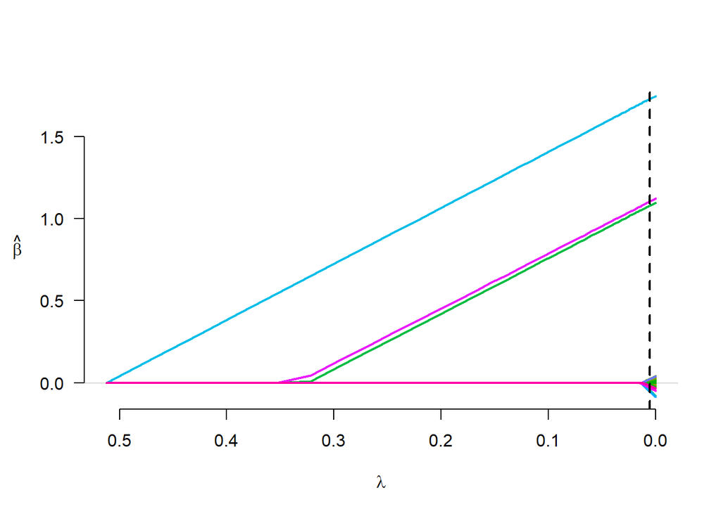

```r
coefficients_at_min_lambda <- coef(grouplasso, lambda = min_lambda)

plot(grouplasso, lwd=2)
abline(v=grouplasso.cv$lambda.min, col = 'black', lty = 2, lwd =2)
```

```r
# # Extract coefficients at the optimal lambda
coefficients_at_min_lambda
```

```
##                 (Intercept)   Education_Level.Associate
##               -1.8934768898               -0.0174368762
##    Education_Level.Bachelor Education_Level.High School
##               -0.0014233087               -0.0065859662
##      Education_Level.Master         Education_Level.PhD
##                0.0106607508                0.0150093887
##          Job_Satisfaction.1          Job_Satisfaction.2
##               -0.0161156374               -0.0055164948
##          Job_Satisfaction.3          Job_Satisfaction.4
##                0.0013528355                0.0021070108
##          Job_Satisfaction.5      Department.Engineering
##                0.0180630516                0.0080141742
##          Department.Finance               Department.HR
##               -0.0014472604               -0.0023514078
##        Department.Marketing       Department.Operations
##               -0.0055876442                0.0008810600
##            Department.Sales         Work_Life_Balance.1
##                0.0005971397               -0.0119863602
##         Work_Life_Balance.2         Work_Life_Balance.3
##               -0.0098540010               -0.0169068807
##         Work_Life_Balance.4         Work_Life_Balance.5
##                0.0244705312                0.0135501489
##   Promotions_Last_5_Years.0   Promotions_Last_5_Years.1
##                0.0030660291               -0.0073158888
##   Promotions_Last_5_Years.2   Promotions_Last_5_Years.3
##                0.0027641211               -0.0004675504
##   Promotions_Last_5_Years.4                         Age
##                0.0018565130                1.0794817446
##                      Salary                  Experience
##               -0.0445324472                1.7300600328
##                Annual_Bonus                Commute_Time
##               -0.0530046435                0.0224549365
##         Work_Hours_Per_Week    Training_Hours_Last_Year
##                1.1056476278               -0.0312153713
##     Overtime_Hours_Per_Week
##               -0.0189209894
```

```r
coefficients_at_min_lambda[c("Age", "Experience", "Work_Hours_Per_Week")]
```

```
##                 Age          Experience Work_Hours_Per_Week
##            1.079482            1.730060            1.105648
```

Based on group LASSO, most coefficients were shrinked to zero or close to zero, except three: Age, Experience, and Work_Hours_Per_week. This findings aligned with our correlation analysis in EDA, and significant analysis with 100 times iterative sub sampling.

This concludes the work in feature selection. Moving forward we will focus on the 3 predictors identified above.

Next we will proceed to model selection with cross-validation.

full MLR model reduced MLR model reduced MLR model with interactive terms (Are the interactive terms between these three predictors having predicting power?) decision tree random forest random forest (MT): manual tuned mtry parameter xgboost xgboost (MT) manual tuned: The final values used for the model were nrounds = 100, max_depth = 3, eta = 0.1, gamma = 0, colsample_bytree = 0.6, min_child_weight = 10 and subsample = 0.6.

**5-fold cross validation for different models**

**Full MLR MOdel**

```r
# linear regression - full model
library(caret)
#
# subsample = sample(8000, 800, replace=FALSE)
# subdata_train = perf_train[subsample,]

# Define 5-fold cross-validation
train_control <- trainControl(method = "cv", number = 5)

# Train the model using linear regression
cv_MLR_full <- caret::train(Performance_Score ~ .,
                  data = perf_train,
                  method = "lm",
                  trControl = train_control)

# Check the results
summary(cv_MLR_full$finalModel)
```

```
##
## Call:
## lm(formula = .outcome ~ ., data = dat)
##
## Residuals:
##     Min      1Q  Median      3Q     Max
## -33.912  -6.682   0.006   6.612  38.685
##
## Coefficients:
##                               Estimate Std. Error t value Pr(>|t|)
## (Intercept)                   1.637662   0.950030   1.724   0.0848 .
## Age                           0.298030   0.007514  39.661   <2e-16 ***
## Salary                       -0.010139   0.007442  -1.362   0.1732
## Experience                    0.504613   0.007965  63.353   <2e-16 ***
## Education_LevelBachelor       0.401126   0.354063   1.133   0.2573
## `Education_LevelHigh School`  0.272054   0.352885   0.771   0.4408
## Education_LevelMaster         0.759506   0.349982   2.170   0.0300 *
## Education_LevelPhD            0.836474   0.353711   2.365   0.0181 *
## Job_Satisfaction2             0.287815   0.353658   0.814   0.4158
## Job_Satisfaction3             0.452780   0.356336   1.271   0.2039
## Job_Satisfaction4             0.466753   0.356383   1.310   0.1903
## Job_Satisfaction5             0.914510   0.357058   2.561   0.0104 *
## DepartmentFinance            -0.487309   0.387697  -1.257   0.2088
## DepartmentHR                 -0.558564   0.391885  -1.425   0.1541
## DepartmentMarketing          -0.733127   0.391747  -1.871   0.0613 .
## DepartmentOperations         -0.375042   0.387573  -0.968   0.3332
## DepartmentSales              -0.397888   0.390967  -1.018   0.3089
## Work_Life_Balance2            0.046985   0.353843   0.133   0.8944
## Work_Life_Balance3           -0.106027   0.354978  -0.299   0.7652
## Work_Life_Balance4            0.845025   0.349135   2.420   0.0155 *
## Work_Life_Balance5            0.578658   0.357180   1.620   0.1053
## Annual_Bonus                 -0.008590   0.005603  -1.533   0.1253
## Commute_Time                  0.004741   0.003378   1.404   0.1605
## Work_Hours_Per_Week           0.399449   0.009671  41.303   <2e-16 ***
## Promotions_Last_5_Years1     -0.581547   0.358819  -1.621   0.1051
## Promotions_Last_5_Years2     -0.035255   0.357074  -0.099   0.9214
## Promotions_Last_5_Years3     -0.208942   0.355965  -0.587   0.5572
## Promotions_Last_5_Years4     -0.089631   0.352908  -0.254   0.7995
## Training_Hours_Last_Year     -0.006873   0.003871  -1.775   0.0759 .
## Overtime_Hours_Per_Week      -0.025371   0.019306  -1.314   0.1888
## ---
## Signif. codes:  0 '***' 0.001 '**' 0.01 '*' 0.05 '.' 0.1 ' ' 1
##
## Residual standard error: 10 on 7970 degrees of freedom
## Multiple R-squared:  0.4815, Adjusted R-squared:  0.4796
## F-statistic: 255.2 on 29 and 7970 DF,  p-value: < 2.2e-16
```

**Reduced MLR Model**

```r
# linear regression - reduced model
cv_MLR <- caret::train(Performance_Score ~ Age + Experience + Work_Hours_Per_Week,
                  data = perf_train,
                  method = "lm",
                  trControl = train_control)

# Check the results
summary(cv_MLR$finalModel)
```

```
##
## Call:
## lm(formula = .outcome ~ ., data = dat)
##
## Residuals:
##     Min      1Q  Median      3Q     Max
## -34.844  -6.675  -0.027   6.632  37.839
##
## Coefficients:
##                     Estimate Std. Error t value Pr(>|t|)
## (Intercept)         0.916158   0.550889   1.663   0.0963 .
## Age                 0.298910   0.007514  39.780   <2e-16 ***
## Experience          0.505382   0.007961  63.482   <2e-16 ***
## Work_Hours_Per_Week 0.399168   0.009671  41.273   <2e-16 ***
## ---
## Signif. codes:  0 '***' 0.001 '**' 0.01 '*' 0.05 '.' 0.1 ' ' 1
##
## Residual standard error: 10.01 on 7996 degrees of freedom
## Multiple R-squared:  0.4786, Adjusted R-squared:  0.4784
## F-statistic:  2446 on 3 and 7996 DF,  p-value: < 2.2e-16
```

**Reduced MLR MOdel with Interactive Terms**

Adding 3 interactive terms for testing:

```r
perf_int <- perf[,c("Age", "Experience", "Work_Hours_Per_Week", "Performance_Score")]
perf_int$AgeExp = perf_int$Age * perf_int$Experience
perf_int$AgeHour = perf_int$Age * perf_int$Work_Hours_Per_Week
perf_int$HourExp = perf_int$Work_Hours_Per_Week * perf_int$Experience
perf_int$all = perf_int$Age * perf_int$Experience * perf_int$Work_Hours_Per_Week
dim(perf_int)
```

```
## [1] 10000     8
```

```r
perf_int_test = perf_int[testRows, ]
perf_int_train = perf_int[-testRows, ]
dim(perf_int_train)
```

```
## [1] 8000    8
```

```r
# linear regression - reduced model
cv_MLR_inter <- caret::train(Performance_Score ~ .,
                  data = perf_int_train,
                  method = "lm",
                  trControl = train_control)

# Check the results
summary(cv_MLR_inter$finalModel)
```

```
##
## Call:
## lm(formula = .outcome ~ ., data = dat)
##
## Residuals:
##     Min      1Q  Median      3Q     Max
## -34.275  -6.671  -0.014   6.665  38.235
##
## Coefficients:
##                       Estimate Std. Error t value Pr(>|t|)
## (Intercept)          7.605e+00  2.469e+00   3.080 0.002078 **
## Age                  1.390e-01  5.357e-02   2.595 0.009477 **
## Experience           3.113e-01  8.723e-02   3.569 0.000361 ***
## Work_Hours_Per_Week  2.209e-01  6.019e-02   3.669 0.000245 ***
## AgeExp               4.692e-03  1.888e-03   2.485 0.012964 *
## AgeHour              4.254e-03  1.307e-03   3.255 0.001138 **
## HourExp              5.260e-03  2.126e-03   2.474 0.013385 *
## all                 -1.266e-04  4.587e-05  -2.760 0.005785 **
## ---
## Signif. codes:  0 '***' 0.001 '**' 0.01 '*' 0.05 '.' 0.1 ' ' 1
##
## Residual standard error: 10.01 on 7992 degrees of freedom
## Multiple R-squared:  0.4793, Adjusted R-squared:  0.4788
## F-statistic:  1051 on 7 and 7992 DF,  p-value: < 2.2e-16
```

```r
cat("Adj. R^2 for cv_MLR_full is",summary(cv_MLR_full)$adj.r.squared)
```

```
## Adj. R^2 for cv_MLR_full is 0.4796276
```

```r
cat("\nAdj. R^2 for cv_MLR_reduced is",summary(cv_MLR$finalModel)$adj.r.squared)
```

```
##
## Adj. R^2 for cv_MLR_reduced is 0.4783646
```

```r
cat("\nAdj. R^2 for cv_MLR_inter is",summary(cv_MLR_inter$finalModel)$adj.r.squared)
```

```
##
## Adj. R^2 for cv_MLR_inter is 0.4788254
```

With the interactive terms, adjusted R^2 did not improve a lot. So interactive terms may not help to improve the model.

```r
# decision tree
library(caret)
library(rpart)
```

```r
library(rpart.plot)
cv_tree <- caret::train(Performance_Score ~ Age + Experience + Work_Hours_Per_Week,
                  data = perf_train,
                  method = "rpart",
                  trControl = train_control)
# Check the results
cv_tree$finalModel
```

```
## n= 8000
##
## node), split, n, deviance, yval
##       * denotes terminal node
##
## 1) root 8000 1537046.0 42.32487
##   2) Experience< 26.5 4263  651194.0 36.44363
##     4) Work_Hours_Per_Week< 40.5 2181  284499.2 32.15881 *
##     5) Work_Hours_Per_Week>=40.5 2082  284705.6 40.93220 *
##   3) Experience>=26.5 3737  570192.5 49.03391 *
```

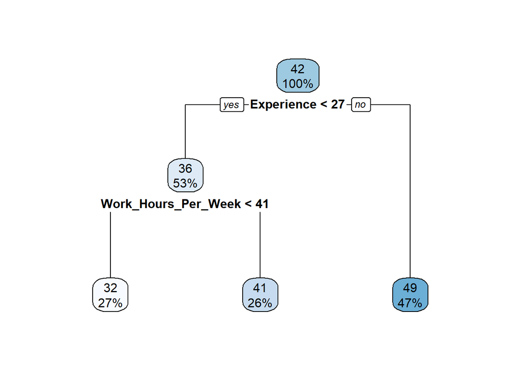

```r
rpart.plot(cv_tree$finalModel)
```

```r
# random forest
library(randomForest)
cv_forest <- caret::train(Performance_Score ~ Age + Experience + Work_Hours_Per_Week,
                  data = perf_train,
                  method = "rf",
                  trControl = train_control)
summary(cv_forest$finalModel)
```

```
##                 Length Class      Mode
## call               4   -none-     call
## type               1   -none-     character
## predicted       8000   -none-     numeric
## mse              500   -none-     numeric
## rsq              500   -none-     numeric
## oob.times       8000   -none-     numeric
## importance         3   -none-     numeric
## importanceSD       0   -none-     NULL
## localImportance    0   -none-     NULL
## proximity          0   -none-     NULL
## ntree              1   -none-     numeric
## mtry               1   -none-     numeric
## forest            11   -none-     list
## coefs              0   -none-     NULL
## y               8000   -none-     numeric
## test               0   -none-     NULL
## inbag              0   -none-     NULL
## xNames             3   -none-     character
## problemType        1   -none-     character
## tuneValue          1   data.frame list
## obsLevels          1   -none-     logical
## param              0   -none-     list
```

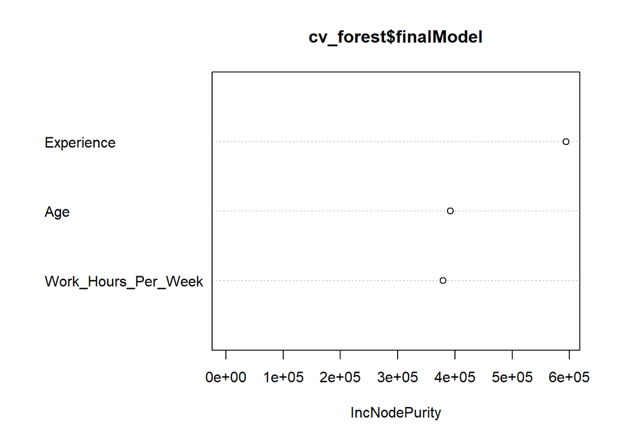

```r
varImpPlot(cv_forest$finalModel)
```

```r
library(xgboost)
cv_xgb <- caret::train(Performance_Score ~ Age + Experience + Work_Hours_Per_Week,
                  data = perf_train,
                  method = "xgbTree",
                  trControl = train_control,
                  tuneLength = 3)
```

[output not shown]

[output cut: 305 more lines]

[output not shown]

```r
summary(cv_xgb$finalModel)
```

```
##               Length Class              Mode
## handle            1  xgb.Booster.handle externalptr
## raw           48740  -none-             raw
## niter             1  -none-             numeric
## call              5  -none-             call
## params            8  -none-             list
## callbacks         1  -none-             list
## feature_names     3  -none-             character
## nfeatures         1  -none-             numeric
## xNames            3  -none-             character
## problemType       1  -none-             character
## tuneValue         7  data.frame         list
## obsLevels         1  -none-             logical
## param             0  -none-             list
```

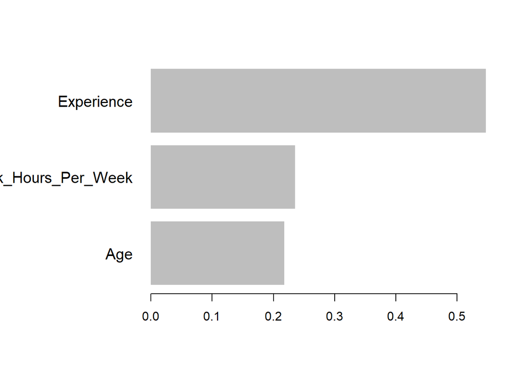

```r
xgb.importance(cv_xgb$finalModel$feature_names, model = cv_xgb$finalModel) %>%
  xgb.plot.importance()
```

**Tune RF model**

```r
# Define the tuning grid for mtry (number of predictors randomly sampled at each split)
tune_grid <- expand.grid(mtry = c(1, 2, 3))

set.seed(123) # for reproducibility

rf_model <- train(Performance_Score ~ Age + Experience + Work_Hours_Per_Week,
                  data = perf_train,
                  method = "rf",
                  trControl = train_control,
                  tuneGrid = tune_grid,
                  ntree = 500) # specify number of trees, e.g., 500

# Display the best model and tuning results
print(rf_model)
```

```
## Random Forest
##
## 8000 samples
##    3 predictor
##
## No pre-processing
## Resampling: Cross-Validated (5 fold)
## Summary of sample sizes: 6401, 6399, 6398, 6401, 6401
## Resampling results across tuning parameters:
##
##   mtry  RMSE      Rsquared   MAE
##   1     10.44100  0.4339122  8.307520
##   2     10.77286  0.4069546  8.557310
##   3     10.88152  0.3981544  8.644931
##
## RMSE was used to select the optimal model using the smallest value.
## The final value used for the model was mtry = 1.
```

```r
rf_model$bestTune
```

```
##   mtry
## 1    1
```

```r
rf_model$results
```

```
##   mtry     RMSE  Rsquared      MAE    RMSESD RsquaredSD     MAESD
## 1    1 10.44100 0.4339122 8.307520 0.1574422 0.01325693 0.1733238
## 2    2 10.77286 0.4069546 8.557310 0.1454895 0.01219234 0.1501046
## 3    3 10.88152 0.3981544 8.644931 0.1457919 0.01232234 0.1432815
```

mtry = 1 was selected and number of tree is 500.

**Tune XGB model**

```r
# # Define the tuning grid for key parameters
# tune_grid <- expand.grid(
#   nrounds = c(100, 200),             # number of boosting rounds
#   max_depth = c(3, 6, 9),            # maximum depth of each tree
#   eta = c(0.01, 0.1, 0.3),           # learning rate
#   gamma = c(0, 0.1, 1),              # minimum loss reduction
#   colsample_bytree = c(0.6, 0.8, 1), # fraction of features used for each tree
#   min_child_weight = c(1, 5, 10),    # minimum sum of instance weight needed in a child
#   subsample = c(0.6, 0.8, 1)
# )
# set.seed(123) # for reproducibility
# xgb_model <- train(
#   Performance_Score ~ Age + Experience + Work_Hours_Per_Week,
#   data = perf_train,
#   method = "xgbTree",
#   trControl = train_control,
#   tuneGrid = tune_grid
# )
# The final values used for the model were nrounds = 100, max_depth = 3, eta = 0.1, gamma = 0, colsample_bytree = 0.6, min_child_weight = 10 and subsample
#  = 0.6.

tune_grid <- expand.grid(
  nrounds = c(100),             # number of boosting rounds
  max_depth = c(3),            # maximum depth of each tree
  eta = c(0.1),           # learning rate
  gamma = c(0),              # minimum loss reduction
  colsample_bytree = c(0.6), # fraction of features used for each tree
  min_child_weight = c(10),    # minimum sum of instance weight needed in a child
  subsample = c(0.6)
)

set.seed(123) # for reproducibility
xgb_model1 <- train(
  Performance_Score ~ Age + Experience + Work_Hours_Per_Week,
  data = perf_train,
  method = "xgbTree",
  trControl = train_control,
  tuneGrid = tune_grid
)

# Display the best model and tuning results
print(xgb_model1)
```

[output not shown]

```r
xgb_model1$bestTune
```

```
##   nrounds max_depth eta gamma colsample_bytree min_child_weight subsample
## 1     100         3 0.1     0              0.6               10       0.6
```

```r
# xgb_model$results
```

```r
# define function for accuracy measure
mse_fun <- function(pred,dat){mean((pred-dat)^2)}
mae_fun <- function(pred,dat){mean(abs(pred-dat))}
mape_fun <- function(pred,dat){mean(abs(pred-dat)/abs(dat))}
pm_fun <- function(pred,dat){sum((pred-dat)^2)/sum((dat-mean(dat))^2) }
ci_fun <- function(pred.lwr,pred.upr,dat){
  sum(dat<pred.lwr | dat>pred.upr)/length(dat) }

pred_fun <- function(model,perf_test){
  pred = predict(model, perf_test)
  mse_model =  mse_fun(pred, perf_test$Performance_Score)
  mae_model =  mae_fun(pred, perf_test$Performance_Score)
  mape_model = mape_fun(pred, perf_test$Performance_Score)
  pm_model  = pm_fun(pred, perf_test$Performance_Score)
      pred_meas = c(mse_model,mae_model, mape_model, pm_model)
   return(pred_meas)
}
```

```r
fitted_MLR_full = pred_fun(cv_MLR_full, perf_train)
fitted_MLR = pred_fun(cv_MLR, perf_train)
fitted_MLR_inter = pred_fun(cv_MLR_inter, perf_int_train)
fitted_tree = pred_fun(cv_tree, perf_train)
fitted_forest = pred_fun(cv_forest, perf_train)
fitted_forest_tuned = pred_fun(rf_model, perf_train)
fitted_xgb = pred_fun(cv_xgb, perf_train)
fitted_xgb_tuned = pred_fun(xgb_model1, perf_train)

# fitted_MLR_full
# fitted_MLR
# fitted_MLR_inter
# fitted_tree
# fitted_forest
# fitted_xgb

result_fitted <- data.frame(rbind(fitted_MLR_full, fitted_MLR, fitted_MLR_inter, fitted_tree, fitted_forest, fitted_forest_tuned, fitted_xgb, fitted_xgb_tuned))
colnames(result_fitted) <- c("MSE", "MAE", "MAPE", "PM")
result_fitted
```

```
##                           MSE      MAE      MAPE        PM
## fitted_MLR_full      99.61708 7.952679 0.3169760 0.5184858
## fitted_MLR          100.18461 7.972676 0.3182938 0.5214397
## fitted_MLR_inter    100.04604 7.969528 0.3207299 0.5207185
## fitted_tree         142.42467 9.518646 0.4022605 0.7412903
## fitted_forest        33.73630 4.591786 0.1838386 0.1755903
## fitted_forest_tuned  50.74209 5.656621 0.2276950 0.2641019
## fitted_xgb           99.14477 7.927551 0.3167521 0.5160275
## fitted_xgb_tuned     99.09731 7.930190 0.3183326 0.5157806
```

```r
# prediction
prediction_results = data.frame(cbind(perf_test$Performance_Score,
                                      predict(cv_MLR_full, perf_test),
                                      predict(cv_MLR, perf_test),
                                      predict(cv_MLR_inter, perf_int_test),
                                      predict(cv_tree, perf_test),
                                      predict(cv_forest, perf_test),
                                      predict(rf_model, perf_test),
                                      predict(cv_xgb, perf_test),
                                      predict(xgb_model1, perf_test)))

colnames(prediction_results) <- c("Actual Score", "MLR_full", "MLR_reduced", "MLR_inter", "Decision Tree", "Random Forest","Random Forest (MT)", "XGBoost", "XGBoost (MT)")
head(prediction_results, 10)
```

```
##      Actual Score MLR_full MLR_reduced MLR_inter Decision Tree Random Forest
## 5698        23.95 39.46297    38.83673  39.37114      40.93220      41.48460
## 4645        50.55 51.28945    50.68850  50.88804      49.03391      47.02623
## 3488        57.84 45.89332    47.15936  47.29318      49.03391      47.21600
## 8297        31.63 48.21311    48.87194  48.91471      49.03391      53.11099
## 7802        15.18 21.41356    21.57711  21.80630      32.15881      21.94911
## 9954        41.96 31.61937    31.97025  32.13453      32.15881      30.24350
## 1035        61.99 34.36561    33.38614  33.51424      32.15881      29.71566
## 6045        23.00 20.07205    19.89991  20.77953      32.15881      22.37193
## 7230        41.19 42.67477    42.54986  42.38410      32.15881      45.32207
## 7420        71.77 62.34911    60.36739  60.39859      49.03391      58.55382
##      Random Forest (MT)  XGBoost XGBoost (MT)
## 5698           41.26101 40.41150     40.54801
## 4645           46.89921 50.60014     49.77475
## 3488           47.91754 46.63471     47.12660
## 8297           51.32911 48.31907     48.01777
## 7802           22.24885 21.65573     22.54193
## 9954           31.36929 31.09842     32.22253
## 1035           30.31147 31.22599     31.35832
## 6045           22.99653 20.79346     21.10959
## 7230           44.41441 41.66475     41.84135
## 7420           59.62316 60.94551     59.87334
```

```r
pred_MLR_full = pred_fun(cv_MLR_full, perf_test)
pred_MLR = pred_fun(cv_MLR, perf_test)
pred_MLR_inter = pred_fun(cv_MLR_inter, perf_int_test)
pred_tree = pred_fun(cv_tree, perf_test)
pred_forest = pred_fun(cv_forest, perf_test)
pred_forest_tuned = pred_fun(rf_model, perf_test)
pred_xgb = pred_fun(cv_xgb, perf_test)
pred_xgb_tuned = pred_fun(xgb_model1, perf_test)

# pred_MLR_full
# pred_MLR
# pred_MLR_inter
# pred_tree
# pred_forest
# pred_xgb

result <- data.frame(rbind(pred_MLR_full, pred_MLR, pred_MLR_inter, pred_tree, pred_forest, pred_forest_tuned, pred_xgb, pred_xgb_tuned))
colnames(result) <- c("MSE", "MAE", "MAPE", "PM")
result
```

```
##                         MSE      MAE      MAPE        PM
## pred_MLR_full      97.74623 7.823889 0.2365212 0.5111807
## pred_MLR           97.25990 7.795628 0.2354998 0.5086374
## pred_MLR_inter     97.26536 7.799983 0.2355910 0.5086659
## pred_tree         142.19808 9.532922 0.2940877 0.7436493
## pred_forest       112.81805 8.416833 0.2517858 0.5900014
## pred_forest_tuned 104.84098 8.107294 0.2452474 0.5482840
## pred_xgb           97.70374 7.828290 0.2365365 0.5109585
## pred_xgb_tuned     97.89833 7.836061 0.2377965 0.5119762
```

Random forest model showed overfitting. After tuning, the random forest model (MT - manual tuned) is less overfitted. But it’s performance is still not as good as MLR or XGBoost models Multiple linear regression performs best.

```r
# testprediction = predict(cv_xgb, perf_test)
# # MSE - Mean squared prediction error
# mean((perf_test$Performance_Score - testprediction)^2)
# # MAE - Mean absolute prediction errors
# mean(abs(perf_test$Performance_Score - testprediction))
# # MAPE - Mean absolute percentage error
# mean(abs(perf_test$Performance_Score - testprediction)/abs(perf_test$Performance_Score))
# # PM - Precision error
# sum((perf_test$Performance_Score - testprediction)^2)/sum((perf_test$Performance_Score - mean(perf_test$Performance_Score))^2)
```